# ST790 - HW3

Brian Naughton

02/24/2015

1. **Least squares**: Yes, it is convex.  
   *Proof*: $l(\beta)=\frac{1}{2}\|y-X\beta\|^2_2=\frac{1}{2}(y-X\beta)'(y-X\beta) \\ \nabla l(\beta)= -X'y + X'X\beta \\ \nabla^2 l(\beta)=X'X \succeq 0$ Since $\nabla^2 l(\beta)$ is psd, $l(\beta)$ is convex.

   **General least squares**: Yes, it is convex.  
   *Proof*: $l(\beta)=\frac{1}{2}\|y-X\beta\|^2_2=\frac{1}{2}(y-X\beta)'\Omega^{-1}(y-X\beta) \\ \nabla l(\beta)= -X'\Omega^{-1}y + X'\Omega^{-1}X\beta \\ \nabla^2 l(\beta)=X'\Omega^{-1}X = Z'Z \succeq 0,$ where $Z=\Omega^{-1/2}X$. Since $\nabla^2 l(\beta)$ is psd, $l(\beta)$ is convex.

   **Nonlinear least squares**: No, it is not convex.  
   Let $n=1$, $y=0$, $x=1$, $f(x; \beta)=x\beta^2 -1$, $\beta_1=-1$, $\beta_2=1$ and $\theta=0.5$.  
   Then, trying to apply the definition of convexity, the left hand side (LHS) is $l\left(\theta\beta_1+(1-\theta)\beta_2\right) = l(.5-.5) = l(0) = \frac{1}{2}(0-(-1))^2=\frac{1}{2},$ and the right hand side (RHS) is $\theta * l(\beta_1) + (1-\theta)*l(\beta_2 )=.5*l(-1)+.5*l(1) \\ =.5(\frac{1}{2}(0-0)^2)+.5(\frac{1}{2}(0-0)^2)=0.$ For this choice of $\beta$ and $\theta$, the $LHS > RHS$, so $l$ is not convex.
2. **$l_p$ regression**: No, it is not convex for $0 < p < 1$.  
   For example, let $n=2$, $p=0.5$, $\beta_1=(1,0)'$, $\beta_2=(0,1)'$, $y=(0,0)'$, $X=\left(\begin{array}{rr}1 & 0 \\0 & 1\end{array}\right)$ and $\theta=0.5$.  
   Trying to apply the definition of convexity, the LHS is $l(.5\beta_1 + .5\beta_2) = \|(.5, .5)'\|_{.5} = (\sqrt{.5} + \sqrt{.5})^2 = 2,$  
   and the RHS is $.5*l(\beta_1) + .5*l(\beta_2) = (.5(1)+.5(1))^2 = 1.$  
   For this choice of $\beta$ and $\theta$, the $LHS > RHS$, so $l_p$ is not necessarily convex. However, it is convex when $l_p$ is a proper norm, i.e. when $p\geq1$.  
   *Proof*: $l(\theta\beta_1 + (1-\theta)\beta_2)_p = \|y-X(\theta\beta_1 + (1-\theta)\beta_2) \|_p\\ = \|\theta y - \theta X\beta_1 + (1-\theta) y - (1-\theta) X\beta_1 \|_p \\ \leq \|\theta(y-X\beta) \|_p + \|(1-\theta)(y-X\beta) \|_p \\ = \theta\|y-X\beta\|_p + (1-\theta)\|y-X\beta\|_p \\ = \theta l(\beta_1)_p + (1-\theta) l(\beta_2)_p,$ so $l_p$ is convex by the definition for $p\geq1$. Note, the inequality is due to the triangle inequality that is required of proper norms.
3. **Worst $k$ error regression**: Yes, it is convex.  
   *Proof*:
   - First, note that $r_i(\beta)=|y_i - x_i'\beta|$ is convex because it is the $l_1$ norm (see Q2).
   - Let $A_1, \dots, A_s$ be all possible subsets of size $k$ (without replacement) from $\{1, 2, \dots, n\}$, where $s={n \choose k}$.
   - Let $l_j(\beta)=\sum_{i\in A_j}r_i(\beta)$, which is the sum of convex functions, and therefore convex.
   - Finally, notice that $l(\beta)=max\{l_1(\beta), \dots, l_s(\beta)\}=\sum_{i=1}^k r_{(i)}(\beta)$. Since the maximum of convex functions is convex, this proves $l(\beta)$ is convex.
4. **Quantile Regression**: Yes, it is convex.  
   *Proof*: For simplicity, let’s consider the case for $n=1$ (if $l_\tau(\beta)$ is convex for n=1, it is also true for n>1 since it would then be a sum of convex functions, which is convex. Also, for simplicity let $z_1=y_i-x_i'\beta_1$ and $z_2=y_i-x_i'\beta_2$. So, $l_\tau(\theta \beta_1 + (1-\theta) \beta_2) = \rho_\tau(\theta z_1 + (1-\theta)z_2)\\ = (\theta z_1 + (1-\theta)z_2)(\tau - I_{\{ \theta z_1 + (1-\theta)z_2 < 0 \}}) \\ = \theta z_1 (\tau - I_{\{ \theta z_1 + (1-\theta)z_2 < 0\}}) + (1-\theta)z_2 (\tau - I_{\{ \theta z_1 + (1-\theta)z_2 < 0\}}).$ Consider the first part of the above equation
   - If $z_1 >= 0$, then  
     $(\tau - I_{\{ \theta z_1 + (1-\theta)z_2 < 0\}}) \leq \tau = (\tau - I_{\{ \theta z_1 < 0\}}).$ So, $\theta z_1(\tau - I_{\{ \theta z_1 + (1-\theta)z_2 < 0\}}) \leq \theta z_1 (\tau - I_{\{ \theta z_1 < 0\}}).$
   - If $z_1 < 0$, then  
     $(\tau - I_{\{ \theta z_1 + (1-\theta)z_2 < 0\}}) \geq \tau - 1 = (\tau - I_{\{ \theta z_1 < 0\}}).$ So, $\theta z_1(\tau - I_{\{ \theta z_1 + (1-\theta)z_2 < 0\}}) \leq \theta z_1 (\tau - I_{\{ \theta z_1 < 0\}}).$

   A similar proof can be given to show the second part of the equation above: $(1-\theta) z_2(\tau - I_{\{ \theta z_1 + (1-\theta)z_2 < 0\}}) \leq (1-\theta) z_2 (\tau - I_{\{ (1-\theta) z_2 < 0\}}).$  
   Continuing the proof: $l_\tau(\theta \beta_1 + (1-\theta) \beta_2) \leq \theta z_1 (\tau - I_{\{ \theta z_1 < 0\}}) + (1-\theta) z_2 (\tau - I_{\{ (1-\theta) z_2 < 0\}}) \\ = \theta \rho_\tau(z_1) + (1-\theta)\rho_\tau(z_2) = \theta l_\tau(\beta_1) + (1-\theta) l_\tau(\beta_2),$ proving convexity by definition.

   Plot $\rho_\tau(z)$ for $\tau=\{.05,.25,.5\}$. It is clearly convex for the values of $\tau$ here:

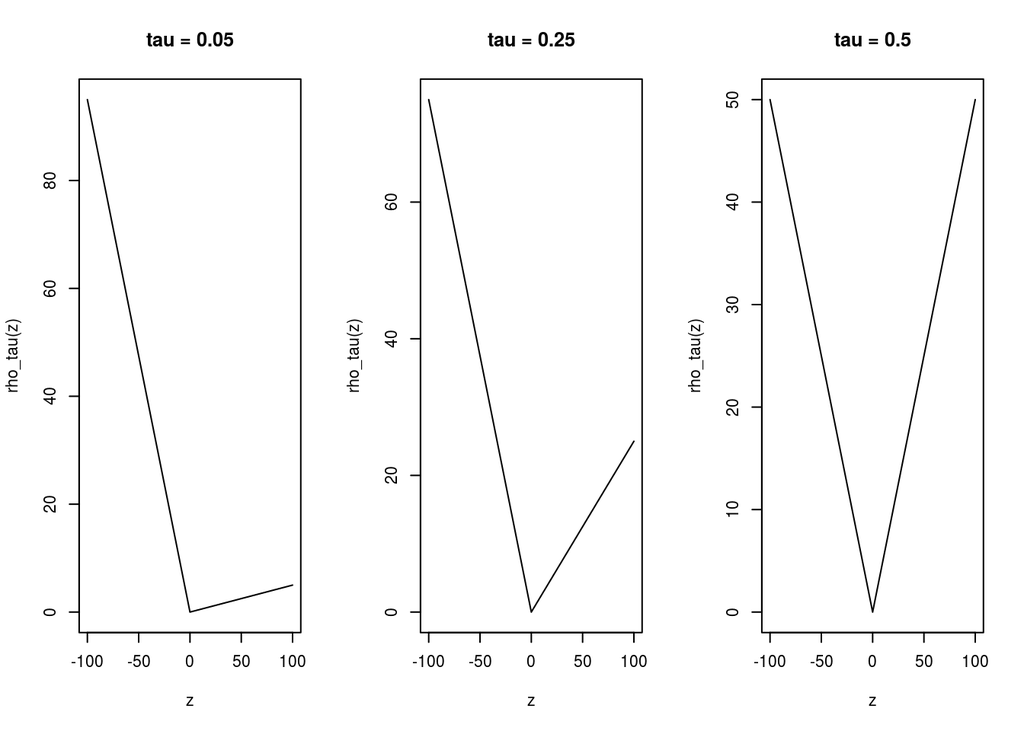

```r
  rho <- function(tau, z) {
    z*(tau-(z<0))
  }
  zs <- -100:100
  par(mfrow=c(1,3))
  for (tau in c(.05, .25, .5)) {
    plot(zs, rho(tau, zs), type='l', main=paste("tau =",tau), xlab="z",
         ylab="rho_tau(z)")
  }
```

5. **Variance component model**: No, it is not convex.  
   Consider the case where $m=2$, $p=2$, $(y-X\beta)=(1,1)'$, $V_1=\left(\begin{array}{rr}1 & 0 \\0 & 5\end{array}\right)$, $V_2=\left(\begin{array}{rr}5 & 0 \\0 & 1\end{array}\right)$, $\sigma_{1a}^2=1$, $\sigma_{2a}^2=0$, $\sigma_{1b}^2=0$, $\sigma_{2a}^2=1$, and $\theta=.5$. To check convexity by using the definition, the LHS is: $l(\theta (\sigma_{1a}^2, \sigma_{2a}^2) + (1-\theta) (\sigma_{1b}^2, \sigma_{2b}^2)) = \\ \frac{1}{2} ln(2\pi) + \frac{1}{2} ln~ det\left(\begin{array}{rr} 3 & 0 \\0 & 3\end{array}\right) + \frac{1}{2}(1,1) \left(\begin{array}{rr} 1/3 & 0 \\0 & 1/3\end{array}\right) \left(\begin{array}{r} 1 \\ 1\end{array}\right) \\ = \frac{1}{2} ln(2\pi) + \frac{1}{2} ln(9) + \frac{1}{3} \approx 2.351.$ The RHS is: $\theta * l( (\sigma_{1a}^2, \sigma_{2a}^2)) + (1-\theta) * l(\sigma_{1b}^2, \sigma_{2b}^2)) \\ = 0.5 \left( \frac{1}{2} ln(2\pi) + \frac{1}{2} ln~ det\left(\begin{array}{rr} 1 & 0 \\0 & 5\end{array}\right) + \frac{1}{2}(1,1) \left(\begin{array}{rr} 1 & 0 \\0 & 1/5\end{array}\right) \left(\begin{array}{r} 1 \\ 1\end{array}\right) \right) \\ + 0.5 \left(\frac{1}{2} ln(2\pi) + \frac{1}{2} ln~ det\left(\begin{array}{rr} 5 & 0 \\0 & 1\end{array}\right) + \frac{1}{2}(1,1) \left(\begin{array}{rr} 1/5 & 0 \\0 & 1\end{array}\right) \left(\begin{array}{r} 1 \\ 1\end{array}\right) \right) \\ = \frac{1}{2} ln(2\pi) + \frac{1}{2} ln(5)+ \frac{3}{5} \approx 2.324.$  
   For these choices of $\beta$, $\sigma_1^2$, $\sigma_2^2$ and $\theta$, the $LHS > RHS$, so $l$ is not convex.
6. **Linear Mixed Model**: No, it is not convex.  
   The negative log-likelihood is $l(\beta, R, \sigma_0^2) = \frac{1}{2} ln(2\pi) + \frac{1}{2} log~det(V) + \frac{1}{2}(y-X\beta)'V^{-1}(y-X\beta),$ where $V=\sigma_0^2 I + ZRZ'$.  
   Note, we can construct a special case of the variance component model from Q5. If we let $Z=\left(\begin{array}{rr} 1 & 0 \\0 & 1\end{array}\right)$, $(y-X\beta)=(1,1)'$, $R_1=\left(\begin{array}{rr} 1/2 & 0 \\0 & 9/2 \end{array}\right)$, $R_2=\left(\begin{array}{rr} 9/2 & 0 \\0 & 1/2 \end{array}\right)$, $\sigma_0^2=\frac{1}{2}$, then $V_1=\left(\begin{array}{rr} 5 & 0 \\0 & 1 \end{array}\right), ~~ V_2=\left(\begin{array}{rr} 1 & 0 \\0 & 5 \end{array}\right),$ which is the exact counter example I showed in Q5.
7. **Gaussian Mixture Model**: No, it is not convex.  
   The negative log-likelihood is $l(\{\pi_j\}_1^k, \{\mu_j\}_1^k, \{\Omega\}_1^k) = -log \left\lbrace \sum_{j=1}^k \pi_j * (2\pi)^{-d/2} | \Omega_j | ^{-1/2} exp\left( \frac{1}{2} (y-\mu_j)'\Omega_j ^ {-1} (y-\mu_j) \right) \right\rbrace$  
   Consider the case where $d=2$, $k=2$, $y=(1,1)'$, $\mu_1=\mu_2=(0,0)'$, $\pi_1=\pi_2=0.5$, $\Omega_{1a}= \left(\begin{array}{rr} 1 & 0 \\0 & 1\end{array}\right)$, $\Omega_{2a}= \left(\begin{array}{rr} 3 & 0 \\0 & 3\end{array}\right)$, $\Omega_{1b}= \left(\begin{array}{rr} 5 & 0 \\0 & 5\end{array}\right)$, $\Omega_{2b}= \left(\begin{array}{rr} 3 & 0 \\0 & 3\end{array}\right)$, and $\theta=0.5$.  
   To check convexity by using the definition, the LHS is: $l\left(\theta \left\lbrace \Omega_{1a}, \Omega_{2a} \right\rbrace + (1-\theta) \left\lbrace \Omega_{1b}, \Omega_{2b} \right\rbrace\right) = l\left( \left\lbrace \left(\begin{array}{rr} 3 & 0 \\0 & 3\end{array}\right), \left(\begin{array}{rr} 3 & 0 \\0 & 3\end{array}\right) \right\rbrace \right) \\ = -log \left\lbrace (2\pi)^{-1} det \left(\begin{array}{rr} 3 & 0 \\0 & 3\end{array}\right)^{-1/2} exp\left( \frac{1}{2} (1, 1)' \left(\begin{array}{rr} 1/3 & 0 \\0 & 1/3\end{array}\right) \left(\begin{array}{r} 1 \\1 \end{array}\right) \right) \right\rbrace \\ = log(2\pi) + 0.5 * log(9) + \frac{1}{3} \approx 3.27$ The RHS is $\theta * l \left( \left\lbrace \left(\begin{array}{rr} 1 & 0 \\0 & 1\end{array}\right), \left(\begin{array}{rr} 3 & 0 \\0 & 3\end{array}\right) \right\rbrace \right) + (1-\theta) * l \left( \left\lbrace \left(\begin{array}{rr} 5 & 0 \\0 & 5\end{array}\right), \left(\begin{array}{rr} 3 & 0 \\0 & 3\end{array}\right) \right\rbrace \right) \\ = -0.5 log \left( 0.5 (2\pi)^{-1} * 1 * exp\left( -1 \right) + 0.5 (2\pi)^{-1} * 9^{-1/2} * exp\left( -1/3 \right) \right) \\ -0.5 log \left( 0.5 (2\pi)^{-1} * 25^{-1/2} * exp\left( -1/5 \right) + 0.5 (2\pi)^{-1} * 9^{-1/2} * exp\left( -1/3 \right) \right) \\ = -0.5 log \left( \frac{1}{4\pi} * \left( exp( -1) + \frac{1}{3} exp(-1/3) \right) \right) \\ -0.5 log \left( \frac{1}{4\pi} * \left( \frac{1}{5} * exp(-1/5) + \frac{1}{3} exp(-1/3) \right) \right) \\ \approx 3.236$  
   For these choices of $\mu_1$, $\mu_2$, $\pi_1$, $\pi_2$, $\Omega_{1a}$, $\Omega_{1b}$, $\Omega_{2a}$, $\Omega_{2b}$, and $\theta$, the $LHS > RHS$, so $l$ is not convex.
8. **Logistic Regression**: Yes, it is convex.  
   $l(\beta)=-\sum_{i=1}^n \left\lbrace y_ix_i'\beta - ln \left( 1 + exp(x_i'\beta) \right) \right\rbrace \\ = \sum ln \left( 1 + exp(x_i'\beta) \right) - \sum y_ix_i'\beta$
   - Note that $x_i'\beta$ is convex because it is linear. So $-y_ix_i'\beta$ is also convex because it is linear.
   - $exp(x_i'\beta)$ is log-convex, which implies that $1+exp(x_i'\beta)$ is also log-convex. Therefore, $log(1+exp(x_i'\beta)$ is convex.
   - Since $l(\beta)$ is the sum of convex functions, it is also convex.

   **GLM with canonical link**: Yes, it is convex. The negative log-likelihood of a GLM with canonical link is:  
   $l(\beta) = \sum_{i=1}^n \frac{b(x_i'\beta)-y_ix_i'\beta}{a_i(\phi)} \\ \nabla l(\beta) = \sum_{i=1}^n \frac{b'(x_i'\beta)x_i - y_ix_i}{a_i(\phi)} \\ \nabla^2 l(\beta) = \sum_{i=1}^n \frac{b''(x_i'\beta)}{a_i(\phi)}x_i x_i'$ Since $Var(y_i)=b''(x_i'\beta)a(\phi)>0$, then $\frac{b''(x_i'\beta)}{a_i(\phi)}>0$. Also, $x_i x_i' \succeq 0$, so $\nabla^2l(\beta)$ is psd. Therefore, $l(\beta)$ is convex.
9. **Gaussian Covariance estimation**: No, it is not convex.  
   The negative log-likelihood is  
   $l(\Sigma)=\frac{np}{2}log(2\pi) + \frac{n}{2} log~det\Sigma + \frac{1}{2} \sum_{i=1}^n X_i'\Sigma^{-1}X_i.$  
   Consider the case where $n=2$, $p=2$, $X_1=(1,1)'$, $X_2=(2,2)'$, $\Sigma_{1}= \left(\begin{array}{rr} 2 & 0 \\0 & 2\end{array}\right)$, $\Sigma_{2}= \left(\begin{array}{rr} 100 & 0 \\0 & 100\end{array}\right)$, and $\theta=0.5$. To check convexity by using the definition, the LHS is:  
   $l\left(\theta\Sigma_1 + (1-\theta)\Sigma_2 \right) = l\left(\left(\begin{array}{rr} 51 & 0 \\0 & 51\end{array}\right) \right) \\ = 2log(2\pi) + log~det\left(\begin{array}{rr} 51 & 0 \\0 & 51\end{array}\right) \\ + \frac{1}{2} \left\lbrace (1, 1)\left(\begin{array}{rr} 1/51 & 0 \\0 & 1/51\end{array}\right) \left(\begin{array}{r} 1 \\1\end{array}\right) +(2, 2)\left(\begin{array}{rr} 1/51 & 0 \\0 & 1/51\end{array}\right) \left(\begin{array}{r} 2 \\2\end{array}\right) \right\rbrace \\ = 2log(2\pi) + log(2601) + 51 + 204 \approx 266.54$  
   The RHS is  
   $\theta l(\Sigma_1) + (1-\theta)l(\Sigma_2) = .5l\left(\left(\begin{array}{rr} 2 & 0 \\0 & 2\end{array}\right) \right) + .5l\left(\left(\begin{array}{rr} 100 & 0 \\0 & 100\end{array}\right) \right)\\ = 2log(2\pi) + .5 log(4) + .5 log(10000) + 1 + 4 + 50 +200 \\ \approx 263.97$ For these choices of $\Sigma_1$, $\Sigma_2$, and $\theta$, the $LHS > RHS$, so $l$ is not convex.
10. **Gaussian precision matrix estimation**: Yes, it is convex.  
    The negative log-likelihood is  
    $l(\Omega) = \frac{np}{2}log(2\pi) + \frac{n}{2} log~det~\left(\Omega^{-1}\right) + \frac{1}{2} \sum_{i=1}^n X_i'\Omega X_i \\ = \frac{np}{2}log(2\pi) + \frac{n}{2} log\left(det~\Omega\right)^{-1} + \frac{1}{2} \sum_{i=1}^n X_i'\Omega X_i \\ = \frac{np}{2}log(2\pi) - \frac{n}{2} log~det~\Omega + \frac{1}{2} \sum_{i=1}^n X_i'\Omega X_i$
    - The first part of $l(\Omega)$ is constant
    - For the second part, the log determinant of a positive definite matrix is concave. So, the negative log det is convex.
    - The last part is linear in $\Omega$, so it is convex. To see this, define $f(\Omega)=X'\Omega X$ for some $X$: $f\left(\theta\Omega_1 +(1-\theta)\Omega_2\right) = X'\left(\theta\Omega_1 +(1-\theta)\Omega_2 \right)X \\ = \theta X'\Omega_1 X + (1-\theta) X'\Omega_2 X\\ = \theta f(\Omega_1) +(1-\theta)f(\Omega_2).$
    - So $l(\Omega)$ is a sum of convex functions, which is convex.